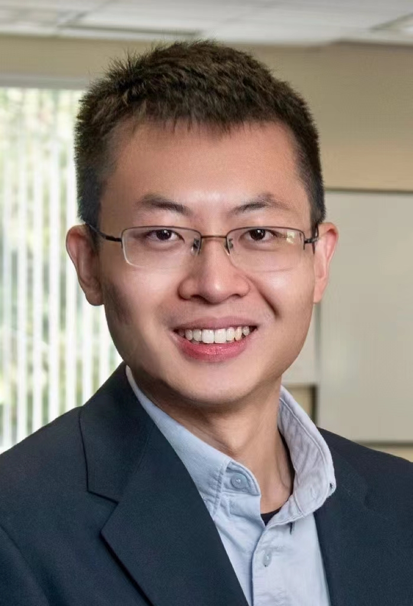

# Sirui Wan

I am a developmental psychologist studying how young people develop an understanding of themselves and their future possibilities and how they make choices that shape their lives. Drawing on large-scale longitudinal surveys, institutional records, meta-analyses, and field experiments, my work examines psychological processes in real-world settings.

I am currently an Assistant Professor of Psychology at the University of Mississippi. I completed my postdoctoral training in the Department of Psychology at the University of Wisconsin–Madison and earned my Ph.D. from the School of Education at the University of California, Irvine.

My work has been published in journals such as *Psychological Bulletin*, *Proceedings of the National Academy of Sciences*, *Child Development*, and *Journal of Educational Psychology*. I have received awards from leading professional organizations, including [the American Psychological Association](https://www.apa.org/science/awards/2021-dissertation-research-award), [the American Educational Research Association](https://www.aera.net/About-AERA/Awards/Division-Awards/2022-Division-Awards), and [the Society for Research on Adolescence](https://srad.memberclicks.net/awards-info). My research is funded by [the Arthur Vining Davis Foundations](https://www.acls.org/programs/avdf-acls-fellowships-for-research-on-the-liberal-arts/).

I am recruiting Ph.D. students through [the Experimental Psychology Program](https://olemiss.edu/psychology/academics/graduate-experimental/) at the University of Mississippi.